# Codebook for Summarized Table of Mean Values (sumdat)

## FFT BodyGyro-std-Z

| Feature | Result |
| --- | --- |
| Variable type | numeric |
| Number of missing obs. | 0 (0 %) |
| Number of unique values | 180 |
| Median | -0.82 |
| 1st and 3rd quartiles | -0.96; -0.39 |
| Min. and max. | -0.99; 0.52 |

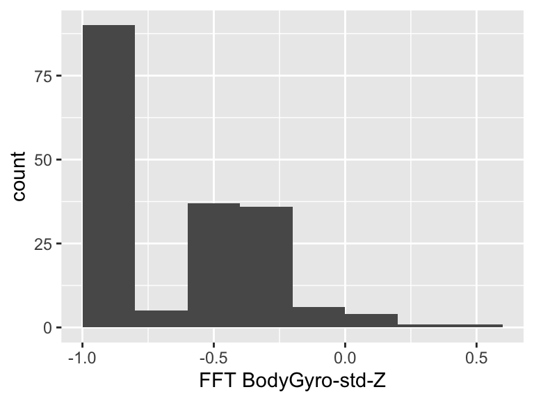

## FFT BodyAccMag-std

| Feature | Result |
| --- | --- |
| Variable type | numeric |
| Number of missing obs. | 0 (0 %) |
| Number of unique values | 180 |
| Median | -0.65 |
| 1st and 3rd quartiles | -0.95; -0.37 |
| Min. and max. | -0.99; 0.18 |

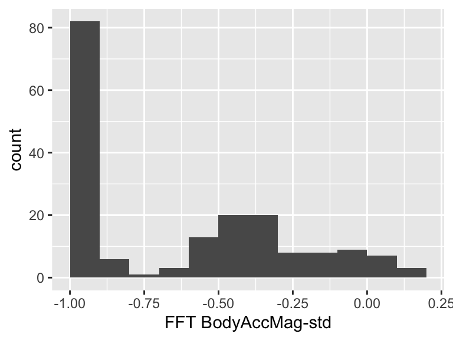

## FFT BodyBodyAccJerkMag-std

| Feature | Result |
| --- | --- |
| Variable type | numeric |
| Number of missing obs. | 0 (0 %) |
| Number of unique values | 180 |
| Median | -0.81 |
| 1st and 3rd quartiles | -0.98; -0.27 |
| Min. and max. | -0.99; 0.32 |

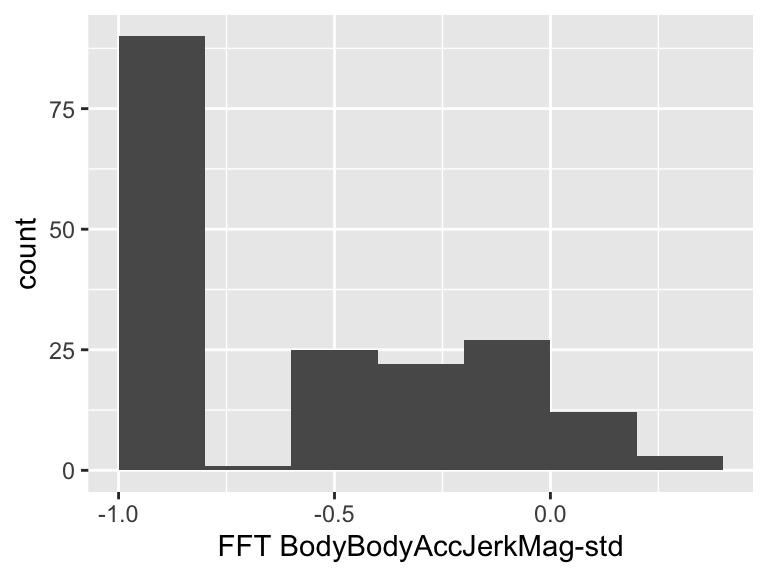

## FFT BodyBodyGyroMag-std

| Feature | Result |
| --- | --- |
| Variable type | numeric |
| Number of missing obs. | 0 (0 %) |
| Number of unique values | 180 |
| Median | -0.77 |
| 1st and 3rd quartiles | -0.95; -0.43 |
| Min. and max. | -0.98; 0.24 |

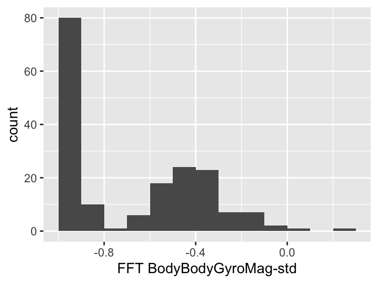

## FFT BodyBodyGyroJerkMag-std

| Feature | Result |
| --- | --- |
| Variable type | numeric |
| Number of missing obs. | 0 (0 %) |
| Number of unique values | 180 |
| Median | -0.89 |
| 1st and 3rd quartiles | -0.98; -0.61 |
| Min. and max. | -1; 0.29 |

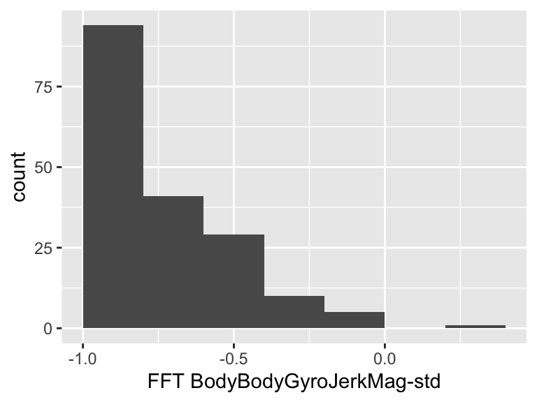

Report generation information:

- Created by: Denis Levert (username: `DenisLevert`).
- Report creation time: Sun Aug 30 2020 09:46:10
- Report was run from directory: `/Users/DenisLevert/Documents/R/R_School/CleanData/Project/HumanActivity`
- dataMaid v1.4.0 [Pkg: 2019-12-10 from CRAN (R 4.0.2)]
- R version 4.0.2 (2020-06-22).
- Platform: x86_64-apple-darwin17.0 (64-bit)(macOS Catalina 10.15.6).
- Function call: `dataMaid::makeDataReport(data = sumdat, mode = c("summarize", "visualize", "check"), smartNum = FALSE, file = "codebook_sumdat.Rmd", checks = list(character = "showAllFactorLevels", factor = "showAllFactorLevels", labelled = "showAllFactorLevels", haven_labelled = "showAllFactorLevels", numeric = NULL, integer = NULL, logical = NULL, Date = NULL), listChecks = FALSE, maxProbVals = Inf, codebook = TRUE, reportTitle = "Codebook for sumdat")`